# Lab 6: Foundations for statistical inference - Sampling distributions

In this lab, we will make sure of the `lattice` and `tidyverse` packages.

```r
library(lattice)
library(tidyverse)
```

We will also make use of the following function that provides us with useful summaries:

```r
favstats = function(mydata){
  # input mydata is a numerical vector or matrices
  result = rep(0, 9);
  mysummary = summary(mydata);
  result[1] = mysummary[1];
  result[2] = mysummary[2];
  result[3] = mysummary[3];
  result[4] = mysummary[4];
  result[5] = mysummary[5];
  result[6] = mysummary[6];
  result[7] = sd(mydata);
  result[8] = length(mydata);
  result[9] = sum(is.na(mydata));
  names(result) = c("min", "Q1", "median", "mean", "Q3", "max", "sd", "n", "missing");
  result;
}
```

In this lab, we investigate the ways in which the statistics from a random sample of data can serve as point estimates for population parameters. We’re interested in formulating a *sampling distribution* of our estimate in order to learn about the properties of the estimate, such as its distribution.

## The Ames Real Estate Data

We consider real estate data from the city of Ames, Iowa. The details of every real estate transaction in Ames is recorded by the City Assessor’s office. Our particular focus for this lab will be all residential home sales in Ames between 2006 and 2010. This collection represents our population of interest. In this lab we would like to learn about these home sales by taking smaller samples from the full population. Let’s load the data.

```r
download.file("http://www.openintro.org/stat/data/ames.RData", destfile = "ames.RData")
load("ames.RData")
```

We see that there are quite a few variables in the data set, enough to do a very in-depth analysis. (A description of all variables can be found at http://www.amstat.org/publications/jse/v19n3/decock/DataDocumentation.txt.) For this lab, we’ll focus our attention to just two of the variables: the above ground living area of the house in square feet (`Gr.Liv.Area`) and the sale price (`SalePrice`). To save some effort throughout the lab, create two variables with short names that represent these two variables.

```r
area = ames$Gr.Liv.Area
price = ames$SalePrice
```

Let’s look at the distribution of area in our population of home sales.

```r
favstats(area)
```

```
##       min        Q1    median      mean        Q3       max        sd         n
##  334.0000 1126.0000 1442.0000 1499.6904 1742.7500 5642.0000  505.5089 2930.0000
##   missing
##    0.0000
```

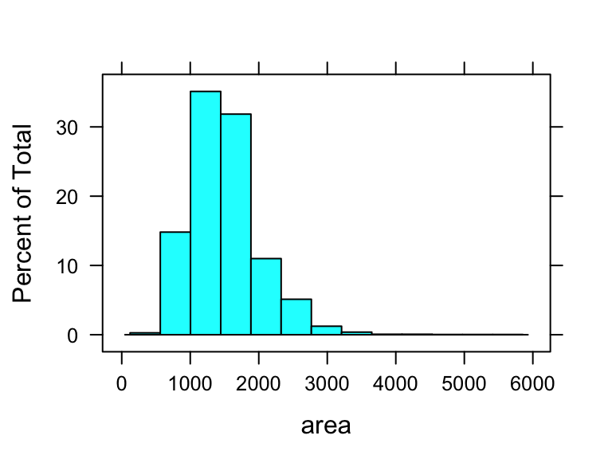

```r
histogram(area)
```

If you would like to adjust the number of class intervals of your histogram, you can do so by specifying the `nint` (for **n**umber of **int**ervals) argument.

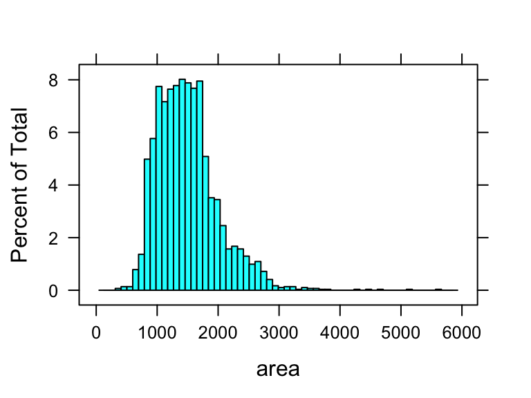

```r
histogram(area, nint=60)
```

The command above gives a histogram with 60 class intervals. Try a number of different values of `nint` until you get a histogram that best depicts the shape of the distribution.

**Exercise 1:** Comment on the shape of this population distribution. Is it symmetric, left-skewed or right-skewed?

## The unknown sampling distribution

In this lab we have access to the entire population, but this is rarely the case in real life.  
Gathering information on an entire population is often extremely costly or impossible.  
Because of this, we often take a sample of the population and use that to understand the properties of the population.

If we were interested in estimating the mean living area in Ames based on a sample, can use the following command to survey the population.

```r
samp1 = sample(area, 50)
```

This command collects a simple random sample of size 50 from the vector `area`, and then store the sample in the variable `samp1`.  
This is like going into the City Assessor’s database and pulling up the files on 50 random home sales.  
Working with these 50 files would be considerably simpler than working with all 2930 home sales.

**Exercise 2:** Describe the distribution of this sample. How does it compare to the distribution of the population?

If we’re interested in estimating the average living area in homes in Ames using the sample, our best single guess is the sample mean.

```r
mean(samp1)
```

[output not shown]

Depending on which 50 homes you selected, your estimate could be a bit above or a bit below the true population mean of 1499.69 square feet. In general, though, the sample mean turns out to be a pretty good estimate of the average living area, and we were able to get it by sampling less than 3% of the population.

**Exercise 3:** Take a second sample, also of size 50, and call it `samp2`. How does the mean of `samp2` compare with the mean of `samp1`? Suppose we took two more samples, one of size 100 and one of size 1000. Which would you think would provide a more accurate estimate of the population mean?

Not surprisingly, every time we take another random sample, we get a different sample mean. It’s useful to get a sense of just how much variability we should expect when estimating the population mean this way. The distribution of sample means, called the *sampling distribution*, can help us understand this variability. In this lab, because we have access to the population, we can build up the sampling distribution for the sample mean by repeating the above steps many times.

Computing a single sample mean is easy:

```r
samp = mean(sample(area, 50))
```

But how can we compute, say, 5000 sample means, and put those results into a data frame to get a sampling distribution? We can use the `replicate` function in R, which is a useful tool for repeating a procedure.

```r
sample_means50 = as.data.frame(replicate(5000, mean(sample(area, 50))))
names(sample_means50) = "mean"
head(sample_means50)
```

```
##      mean
## 1 1345.84
## 2 1445.50
## 3 1561.68
## 4 1495.90
## 5 1484.46
## 6 1580.90
```

We can examine the sampling distribution from the summary statistics and the histogram.

```r
favstats(sample_means50$mean)
```

```
##        min         Q1     median       mean         Q3        max         sd
## 1187.56000 1451.52500 1498.33000 1499.87481 1546.10500 1780.10000   71.38532
##          n    missing
## 5000.00000    0.00000
```

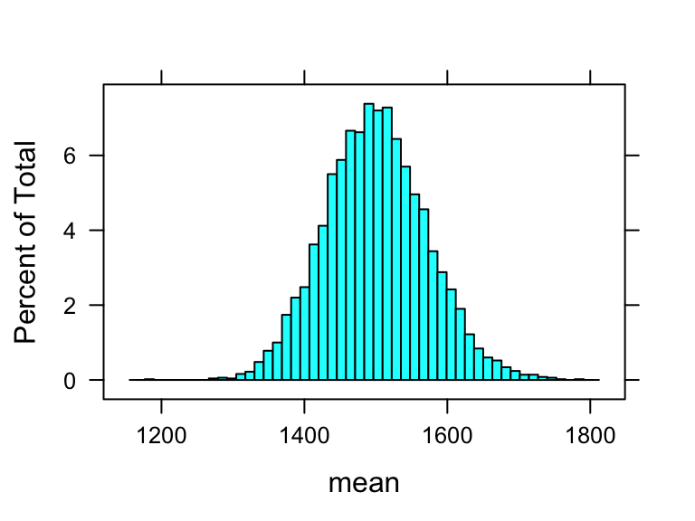

```r
histogram(sample_means50$mean, nint=50, xlab="mean")
```

Again you should try a number of different `nint` values until you get a histogram that best displays the shape of the distribution. You can overlay a normal density on the histogram using the same approach in Lab 5.

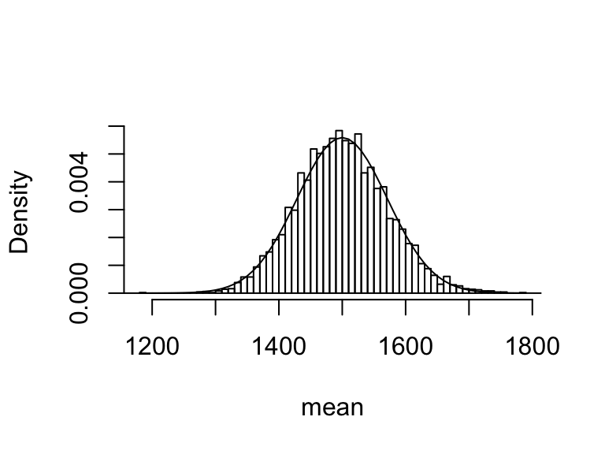

```r
hist(sample_means50$mean, breaks = 50, freq=F,
     xlab="mean", main='')
x = seq(1000, 2000, by=10);
y = dnorm(x, mean(sample_means50$mean),
          sd(sample_means50$mean))
lines(x, y)
```

**Exercise 4:** How many elements are there in `sample_means50`? Describe the sampling distribution, and be sure to specifically note its center. Would you expect the distribution to change if we instead collected 50,000 sample means?